# BioCRNpyler: Compiling Chemical Reaction Networks from Parts in Diverse Contexts with Python

Navigation Instructions:

- Right/Left Arrow to navigate sections.
- Down Arrow for more information in a section.

# Installation

GitHub: https://github.com/BuildACell/BioCRNPyler

```
git clone https://github.com/BuildACell/BioCRNPyler
```

PyPi:

```
pip install biocrnpyler[all]
```

# What is BioCRNpyler?

## BioCRNpyler is a Python Library and Framework. It takes high level specifications and converts them into Chemical Reaction Networks (as [SBML](http://co.mbine.org/standards/sbml))

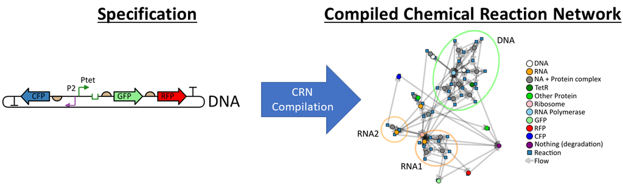

## BioCRNpyler makes model generation easy

## *BioCRNpyler is NOT a CRN Simulator*

```python
#create DNAparts
ptet = RegulatedPromoter("ptet",["tetr"],leak=True) #this is a promoter repressed by tetR
pconst = Promoter("pconst") #constitutive promoter
pcomb = CombinatorialPromoter("pcomb",["arac","laci"], leak=False, tx_capable_list = [["arac"], ["laci"]]) #the Combinations A and B or just A or just B be transcribed
utr1 = RBS("UTR1") #regular RBS
utr2 = RBS("UTR1") #regular RBS
gfp = CDS("GFP","GFP") #a CDS has a name and a protein name.
fusrfp = CDS("fusRFP","RFP",no_stop_codons=["forward"]) #This is different from a fusion protein
rfp = CDS("RFP","RFP") #regular RFP
cfp = CDS("CFP","CFP") #cfp
t16 = Terminator("t16") #a terminator stops transcription

#Combine the parts together in a DNA_construct with their directions
construct = DNA_construct([[ptet,"forward"],[utr1,"forward"],[gfp,"forward"],[t16,"forward"],[t16,"reverse"],[rfp,"reverse"],[utr1,"reverse"],[pconst,"reverse"]])
```

### This is the code to compile a specification into a CRN

*Plotting not shown - but BioCRNpyler automatically produces interactive reaction network graphs to help visualize and debug complex CRNs!*

```python
#some very basic parameters are defined - these are sufficient for the whole model to compile!
parameters={"cooperativity":2,"kb":100, "ku":10, "ktx":.05, "ktl":.2, "kdeg":2,"kint":.05}

#Place the construct in a context (TxTlExtract models a bacterial lysate with machinery like Ribosomes and Polymerases modelled explicitly)
myMixture = TxTlExtract(name = "txtl", parameters = parameters, components = [construct])

#Compile the CRN
myCRN = myMixture.compile_crn()
```

# BioCRNpyler is an Objected Oriented Framework which Compiles CRNs

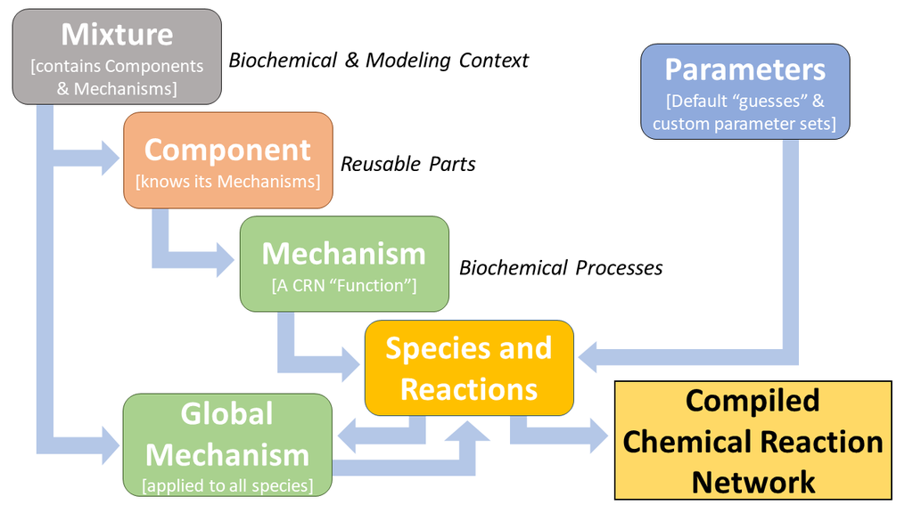

## BioCRNpyler Specifications include Context (the Mixture), Parts (Components), and Biochemical Processes (Mechanisms)

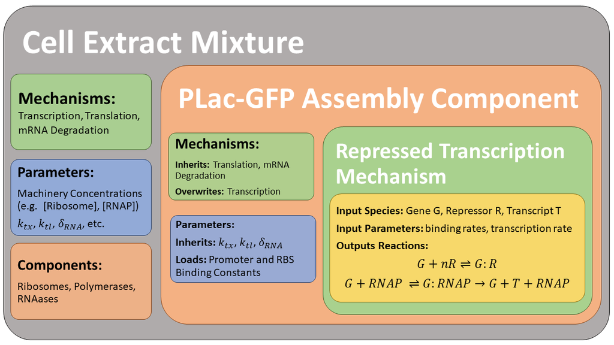

# Getting Started With BioCRNpyler

The best way to get started using BioCRNpyler is to install the software and go through the [example ipython jupyter notebooks in this folder](https://github.com/BuildACell/BioCRNPyler/tree/master/examples). After downloading the software, open a terminal and change directory to the examples folder. Then type:

```
jupyter notebook
```

which will open a jupyter notebook in your browser. Select the tutorial you wish to try (we recommend starting at 1. Building CRNs direction.ipynb) and learn a new, faster way of producing biochemical models!

## Don't feel like installing the software yet? [Demo it online using Binder!](https://mybinder.org/v2/gh/BuildACell/BioCRNPyler/master?filepath=%2Fexamples%2F)